# Avaliação de técnicas de mineração de dados

# Separação dos vinhos em grupos para exportação de vinhos brancos

Nesta etapa iremos separa os vinhos em dois datasets distintos, um para os do tipo “Branco” e outro para vinhos do tipo “Vermelho”.

Vinhos brancos:

Vinhos vermelhos:

Verificamos os dados nos novos datasets criados:

```
## 'data.frame':    4697 obs. of  14 variables:
##  $ fixedacidity      : num  6.6 6.7 5.4 6.7 5.1 6.2 6.6 7.3 6.7 8.1 ...
##  $ volatileacidity   : num  0.24 0.34 0.18 0.3 0.26 0.22 0.25 0.27 0.26 0.25 ...
##  $ citricacid        : num  0.35 0.43 0.24 0.44 0.33 0.2 0.36 0.37 0.29 0.38 ...
##  $ residualsugar     : num  7.7 1.6 4.8 18.8 1.1 ...
##  $ chlorides         : num  0.031 0.041 0.041 0.057 0.027 0.035 0.045 0.042 0.038 0.051 ...
##  $ freesulfurdioxide : num  36 29 30 65 46 58 54 36 40 18 ...
##  $ totalsulfurdioxide: num  135 114 113 224 113 184 180 130 179 129 ...
##  $ density           : num  0.994 0.99 0.994 1 0.989 ...
##  $ pH                : num  3.19 3.23 3.42 3.11 3.35 3.11 3.08 3.48 3.23 3.21 ...
##  $ sulphates         : num  0.37 0.44 0.4 0.53 0.43 0.53 0.42 0.75 0.56 0.38 ...
##  $ alcohol           : num  10.5 12.6 9.4 9.1 11.4 9 9.2 9.9 10.4 11.5 ...
##  $ quality           : int  5 6 6 5 7 6 5 6 6 6 ...
##  $ Vinho             : Factor w/ 2 levels "RED","WHITE": 2 2 2 2 2 2 2 2 2 2 ...
##  $ classificacao     : Factor w/ 2 levels "BOM","RUIM": 2 1 1 2 1 1 2 1 1 1 ...
```

```
## 'data.frame':    1356 obs. of  14 variables:
##  $ fixedacidity      : num  10.6 6.8 6.6 7.2 7.2 7.1 6.4 9 7.3 6.8 ...
##  $ volatileacidity   : num  0.31 0.5 0.61 0.66 0.63 0.735 0.31 0.58 0.735 0.57 ...
##  $ citricacid        : num  0.49 0.11 0 0.33 0 0.16 0.09 0.25 0 0 ...
##  $ residualsugar     : num  2.2 1.5 1.6 2.5 1.9 1.9 1.4 2 2.2 2.5 ...
##  $ chlorides         : num  0.063 0.075 0.069 0.068 0.097 0.1 0.066 0.104 0.08 0.072 ...
##  $ freesulfurdioxide : num  18 16 4 34 14 15 15 8 18 32 ...
##  $ totalsulfurdioxide: num  40 49 8 102 38 77 28 21 28 64 ...
##  $ density           : num  0.998 0.995 0.994 0.994 0.997 ...
##  $ pH                : num  3.14 3.36 3.33 3.27 3.37 3.27 3.42 3.27 3.41 3.43 ...
##  $ sulphates         : num  0.51 0.79 0.37 0.78 0.58 0.64 0.7 0.72 0.6 0.56 ...
##  $ alcohol           : num  9.8 9.5 10.4 12.8 9 9.3 10 9.6 9.4 11.2 ...
##  $ quality           : int  6 5 4 6 6 5 7 5 5 6 ...
##  $ Vinho             : Factor w/ 2 levels "RED","WHITE": 1 1 1 1 1 1 1 1 1 1 ...
##  $ classificacao     : Factor w/ 2 levels "BOM","RUIM": 1 2 2 1 1 2 1 2 2 1 ...
```

## Vinhos brancos

Utilizando os gráficos de Boxplot para checar possiveis outliers:

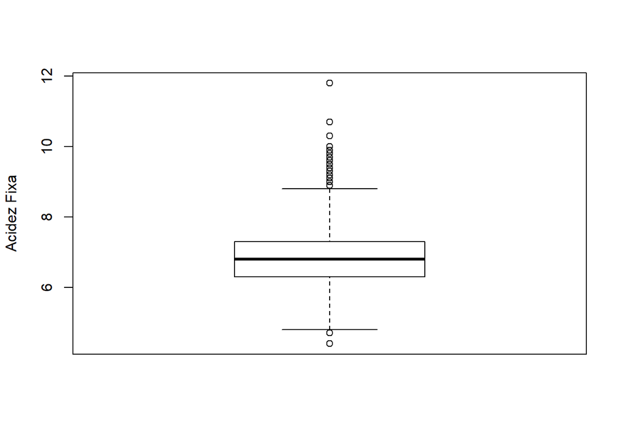

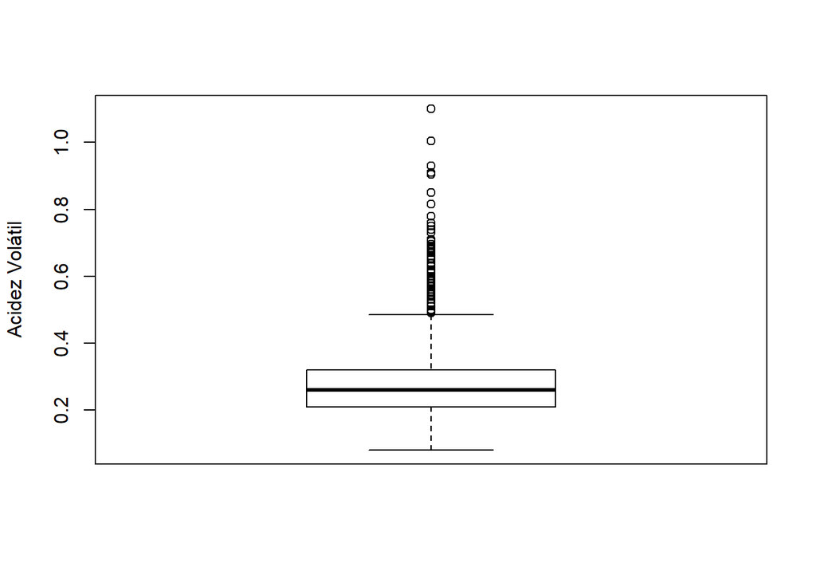

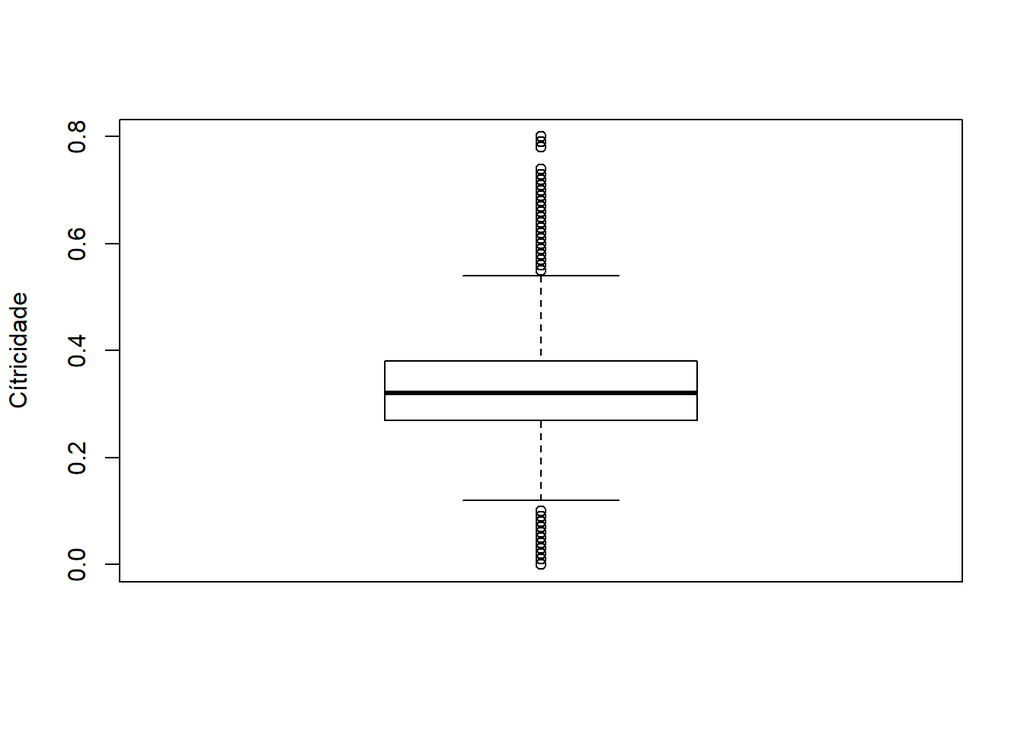

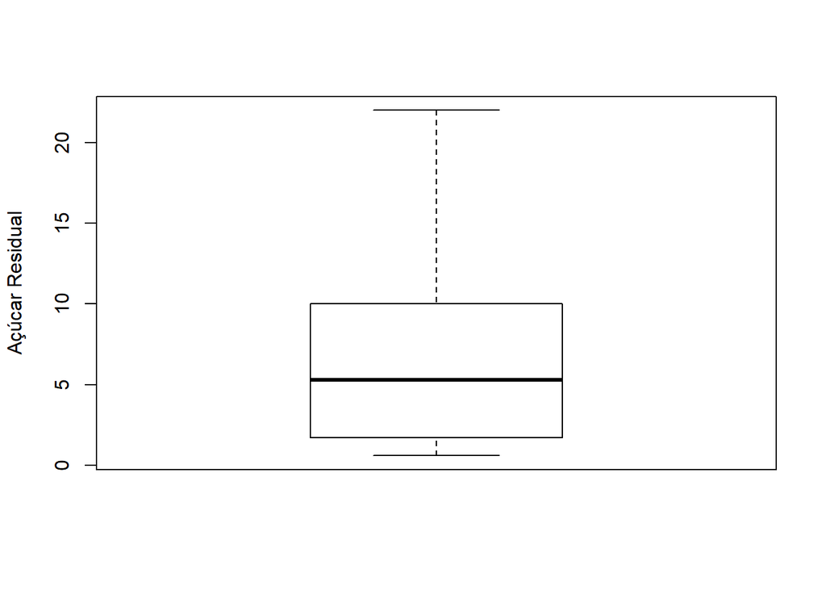

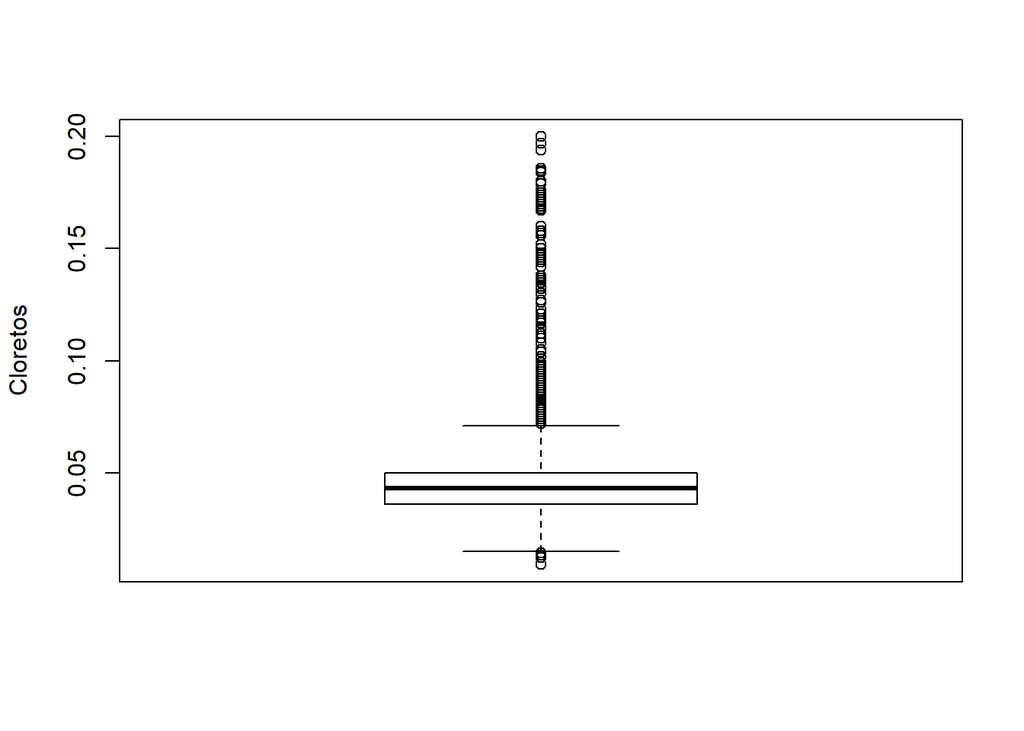

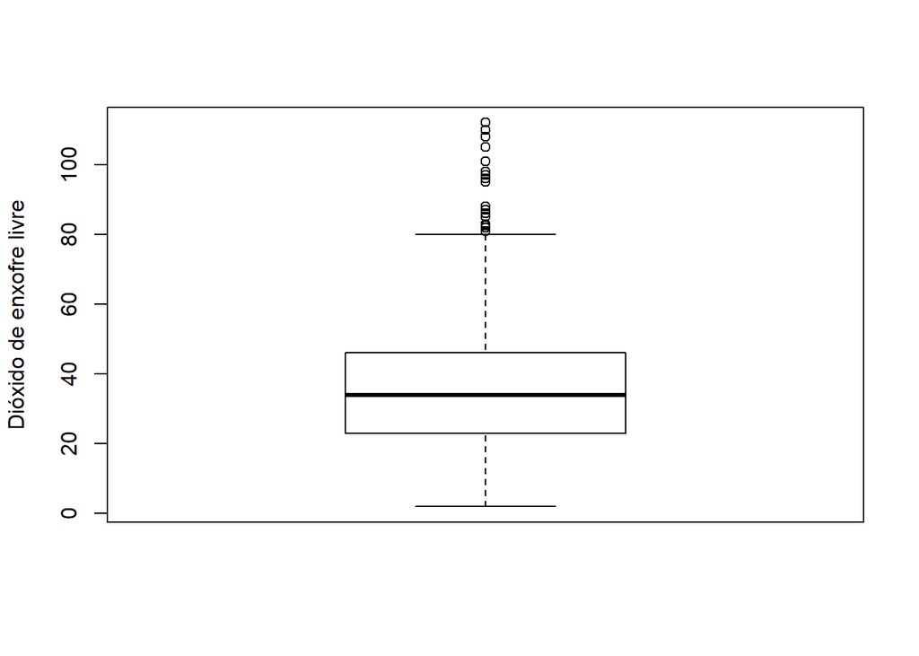

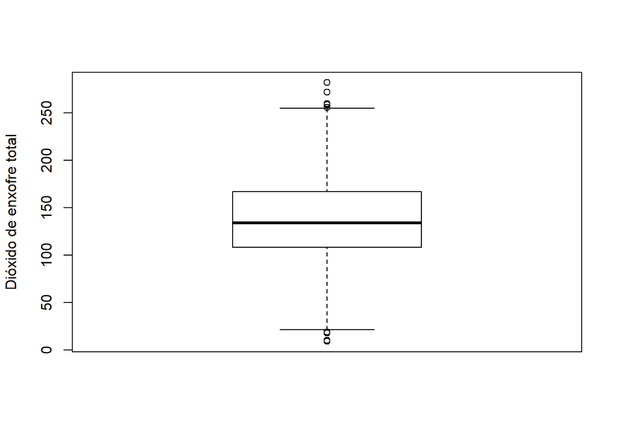

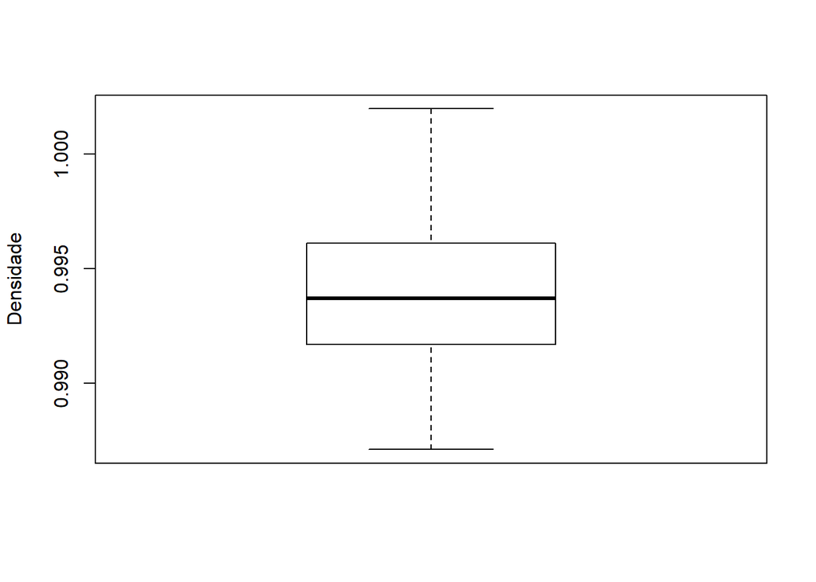

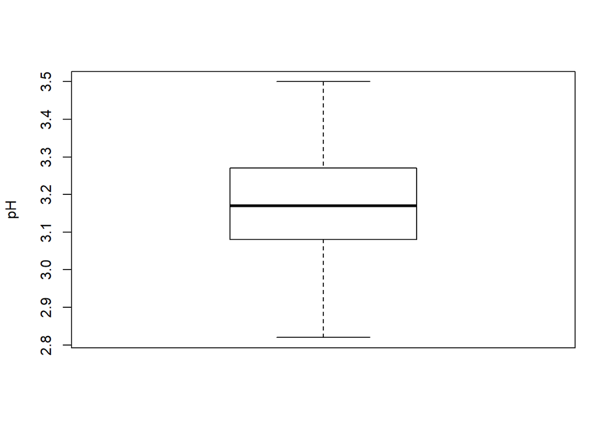

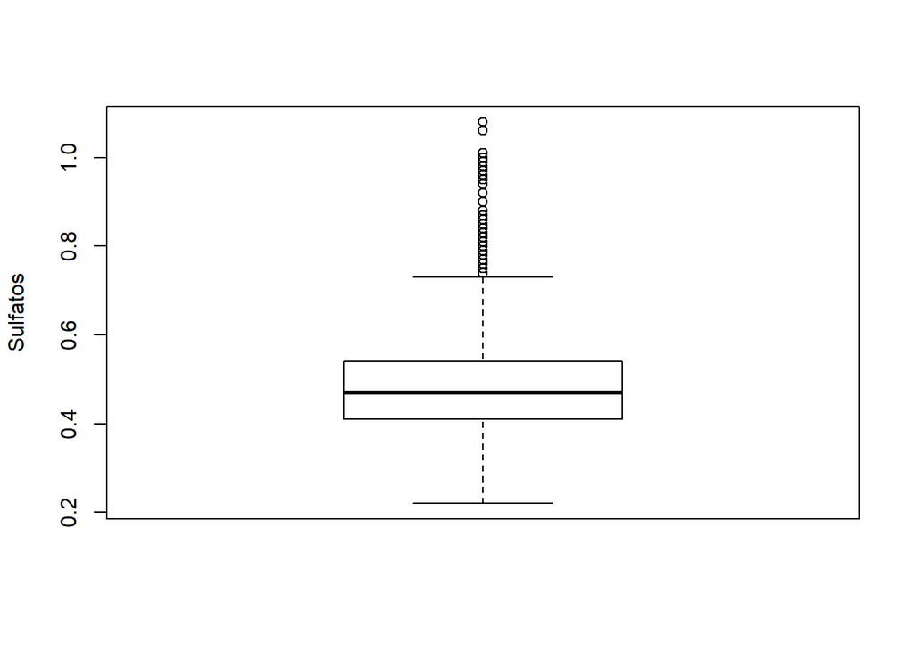

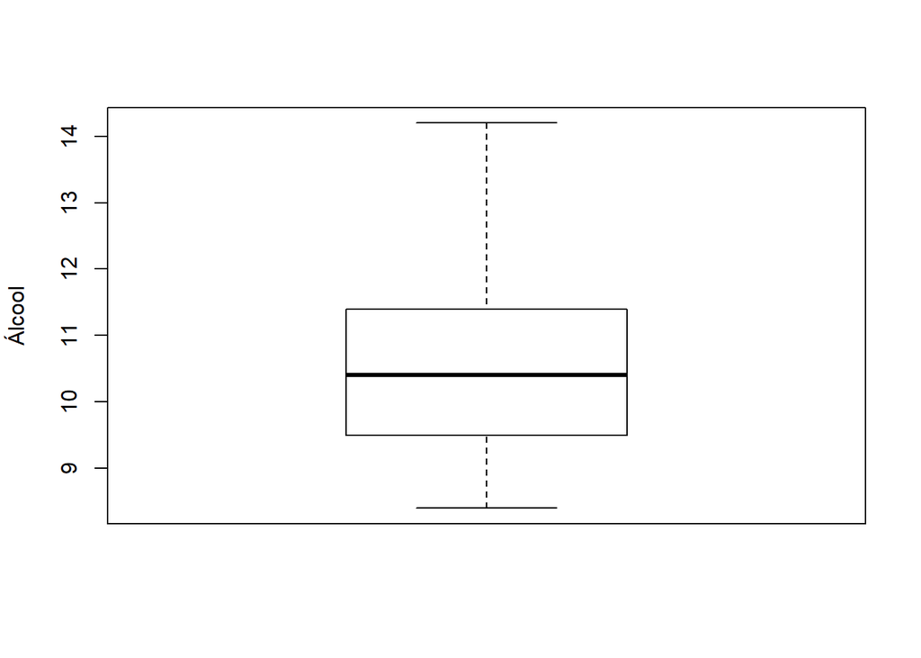

Devido aos dados base já terem sido filtrados nas etapas anteriores não achamos necessário realizar a remoção de mais dados.

Realizamos uma padronização nas variáveis e visualizamos os dados:

```r
Padr_White <- scale(wineData_White %>% select(-Vinho,-classificacao, -quality))
summary(Padr_White)
```

```
##   fixedacidity      volatileacidity     citricacid      residualsugar
##  Min.   :-3.00800   Min.   :-1.9953   Min.   :-2.9116   Min.   :-1.1735
##  1st Qu.:-0.69383   1st Qu.:-0.6893   1st Qu.:-0.5460   1st Qu.:-0.9517
##  Median :-0.08483   Median :-0.1870   Median :-0.1079   Median :-0.2257
##  Mean   : 0.00000   Mean   : 0.0000   Mean   : 0.0000   Mean   : 0.0000
##  3rd Qu.: 0.52416   3rd Qu.: 0.4158   3rd Qu.: 0.4178   3rd Qu.: 0.7221
##  Max.   : 6.00509   Max.   : 8.2518   Max.   : 4.0976   Max.   : 3.1420
##    chlorides       freesulfurdioxide  totalsulfurdioxide    density
##  Min.   :-1.9677   Min.   :-2.04053   Min.   :-3.08653   Min.   :-2.3688
##  1st Qu.:-0.4907   1st Qu.:-0.74425   1st Qu.:-0.71589   1st Qu.:-0.7903
##  Median :-0.1077   Median :-0.06526   Median :-0.09329   Median :-0.1025
##  Mean   : 0.0000   Mean   : 0.00000   Mean   : 0.00000   Mean   : 0.0000
##  3rd Qu.: 0.2752   3rd Qu.: 0.67547   3rd Qu.: 0.69692   3rd Qu.: 0.7228
##  Max.   : 8.4808   Max.   : 4.74946   Max.   : 3.45070   Max.   : 2.7380
##        pH             sulphates          alcohol
##  Min.   :-2.66220   Min.   :-2.3618   Min.   :-1.70852
##  1st Qu.:-0.72630   1st Qu.:-0.6882   1st Qu.:-0.81915
##  Median :-0.05618   Median :-0.1597   Median :-0.09149
##  Mean   : 0.00000   Mean   : 0.0000   Mean   : 0.00000
##  3rd Qu.: 0.68840   3rd Qu.: 0.4569   3rd Qu.: 0.71702
##  Max.   : 2.40092   Max.   : 5.2133   Max.   : 2.98085
```

Aqui estamos fazendo o PCA para analisarmos o peso de cada variável

```r
acpcor <- prcomp(Padr_White, scale = TRUE)
summary(acpcor)
```

```
## Importance of components:
##                          PC1    PC2    PC3     PC4     PC5     PC6     PC7
## Standard deviation     1.820 1.2469 1.1010 1.00643 0.98736 0.95079 0.84215
## Proportion of Variance 0.301 0.1413 0.1102 0.09208 0.08863 0.08218 0.06447
## Cumulative Proportion  0.301 0.4424 0.5526 0.64468 0.73330 0.81548 0.87996
##                            PC8     PC9    PC10    PC11
## Standard deviation     0.78363 0.63249 0.54103 0.11684
## Proportion of Variance 0.05582 0.03637 0.02661 0.00124
## Cumulative Proportion  0.93578 0.97215 0.99876 1.00000
```

Podemos ver que o o PC10 e PC11 tem um peso menor que os demais,ou seja, podem ser retiradas, no entanto decidimos mantê-las.

Checamos a variação de cada variável:

```r
sum(acpcor$sdev^2)
```

```
## [1] 11
```

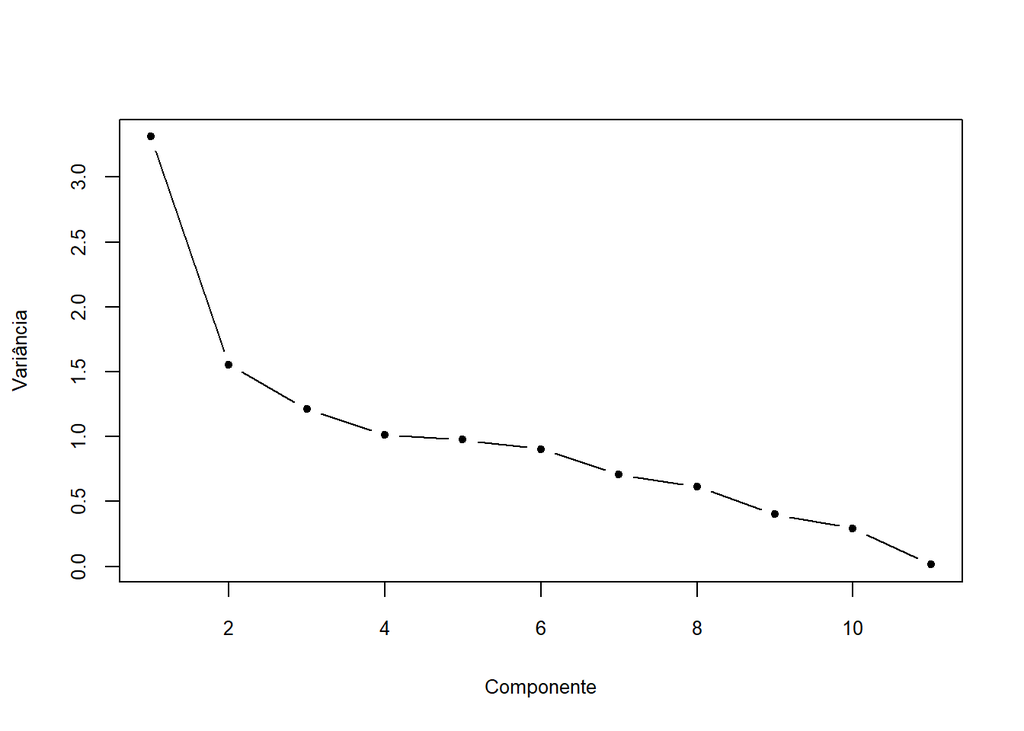

```r
plot(1:ncol(Padr_White), acpcor$sdev^2, type = "b", xlab = "Componente",
     ylab = "Variância", pch = 20, cex.axis = 0.8, cex.lab = 0.8)
```

Assim como a importância de cada uma no PCA:

```r
acpcor$rotation[, 1:11]
```

```
##                            PC1          PC2        PC3         PC4          PC5
## fixedacidity        0.14798093 -0.600651789  0.0389442  0.04086425 -0.262752235
## volatileacidity    -0.01600807  0.124333292 -0.5593300 -0.03058661 -0.701893615
## citricacid          0.14415066 -0.403634390  0.4542291 -0.08760296 -0.058857950
## residualsugar       0.42300461  0.044281062 -0.1886691  0.26647362  0.030836332
## chlorides           0.22194936  0.002333383 -0.1331365 -0.73234575  0.168498500
## freesulfurdioxide   0.30569959  0.256702848  0.3024180  0.38410622  0.004761824
## totalsulfurdioxide  0.40400365  0.224118734  0.1448959  0.15259251 -0.221138688
## density             0.50926745  0.014087814 -0.1244171 -0.02438917  0.026344075
## pH                 -0.13188000  0.561450633  0.1847160 -0.14609115  0.053866189
## sulphates           0.04576815  0.158645776  0.4972093 -0.34989718 -0.555474560
## alcohol            -0.43972715 -0.046393552  0.1293045  0.25921853 -0.210777554
##                           PC6         PC7          PC8         PC9        PC10
## fixedacidity        0.0847276 -0.04599484  0.634397944  0.29697351 -0.13002469
## volatileacidity    -0.2301350  0.25425008 -0.085479430 -0.09416542 -0.20964945
## citricacid         -0.2161292  0.65118658 -0.324390601 -0.14866414 -0.02595188
## residualsugar       0.3229582  0.11651922 -0.394258700  0.45155583  0.12362871
## chlorides          -0.4290252 -0.11551517 -0.058948760  0.40466999  0.05656068
## freesulfurdioxide  -0.4628900 -0.20991201 -0.003194631  0.15273517 -0.56501985
## totalsulfurdioxide -0.2987593 -0.03349747  0.268442609 -0.19437822  0.70094046
## density             0.3264009  0.13304650  0.041077190  0.06370702 -0.06442940
## pH                  0.1661080  0.55542716  0.432730952  0.24847526 -0.09959174
## sulphates           0.3721633 -0.33247692 -0.200712681  0.01210569 -0.05847140
## alcohol            -0.1691845  0.01871333 -0.157441237  0.62138725  0.30320040
##                            PC11
## fixedacidity       -0.168044837
## volatileacidity    -0.010618176
## citricacid         -0.008812549
## residualsugar      -0.468023302
## chlorides          -0.021151848
## freesulfurdioxide   0.026806048
## totalsulfurdioxide -0.042769079
## density             0.767817524
## pH                 -0.118367649
## sulphates          -0.040524493
## alcohol             0.379911399
```

```r
acpcor <- prcomp(Padr_White, scale = TRUE, retx = TRUE)
```

Escolhemos 2 Centróides, pois queremos classificar os vinhos como BOM e RUIM:

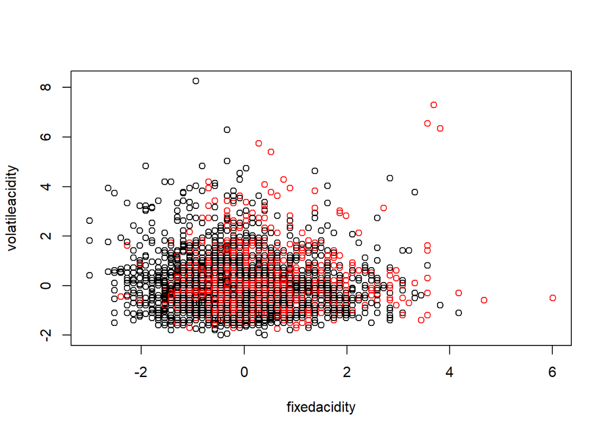

```r
Kcluster <- kmeans(Padr_White, centers =  2)
plot(Padr_White, col=Kcluster$cluster)
```

## Vinhos vermelhos

Utilizando os gráficos de Boxplot para checar possiveis outliers:

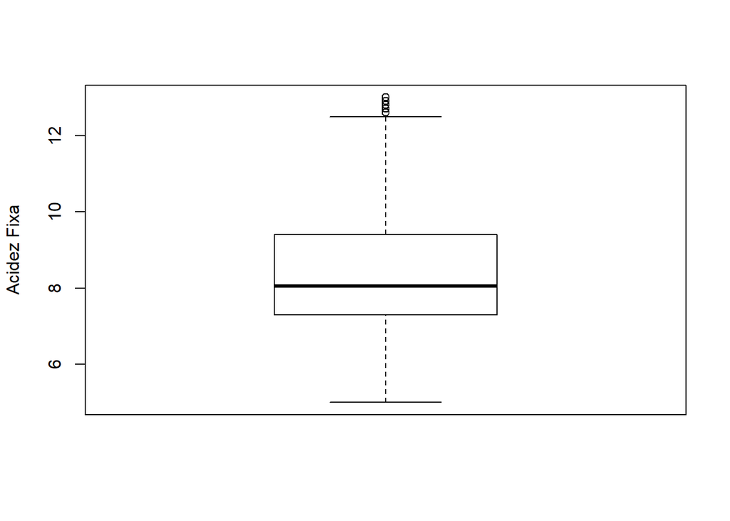

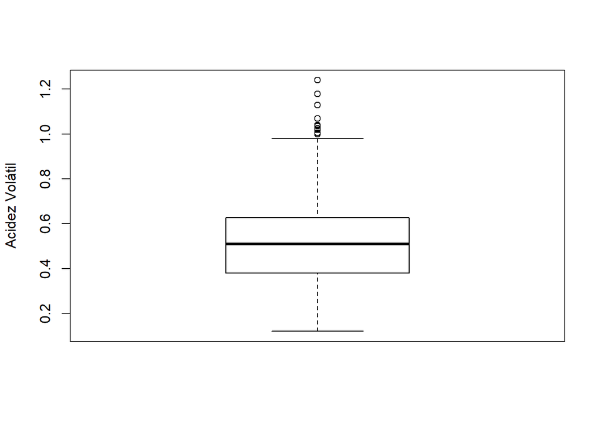

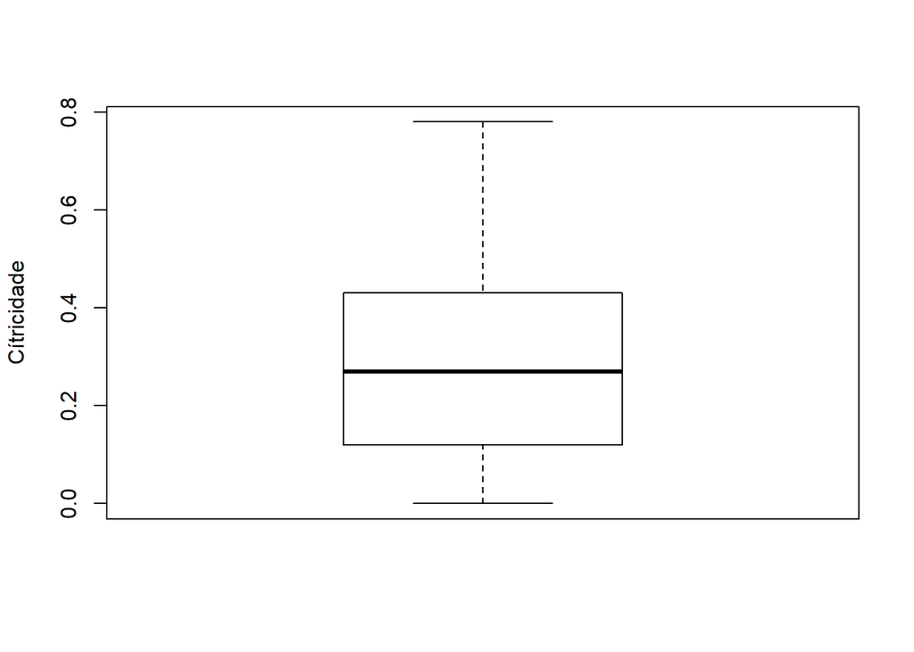

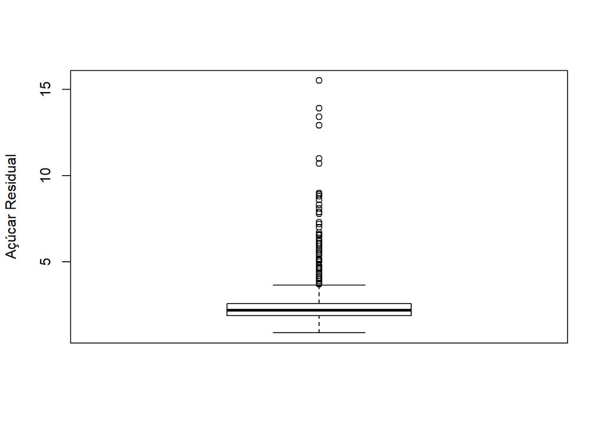

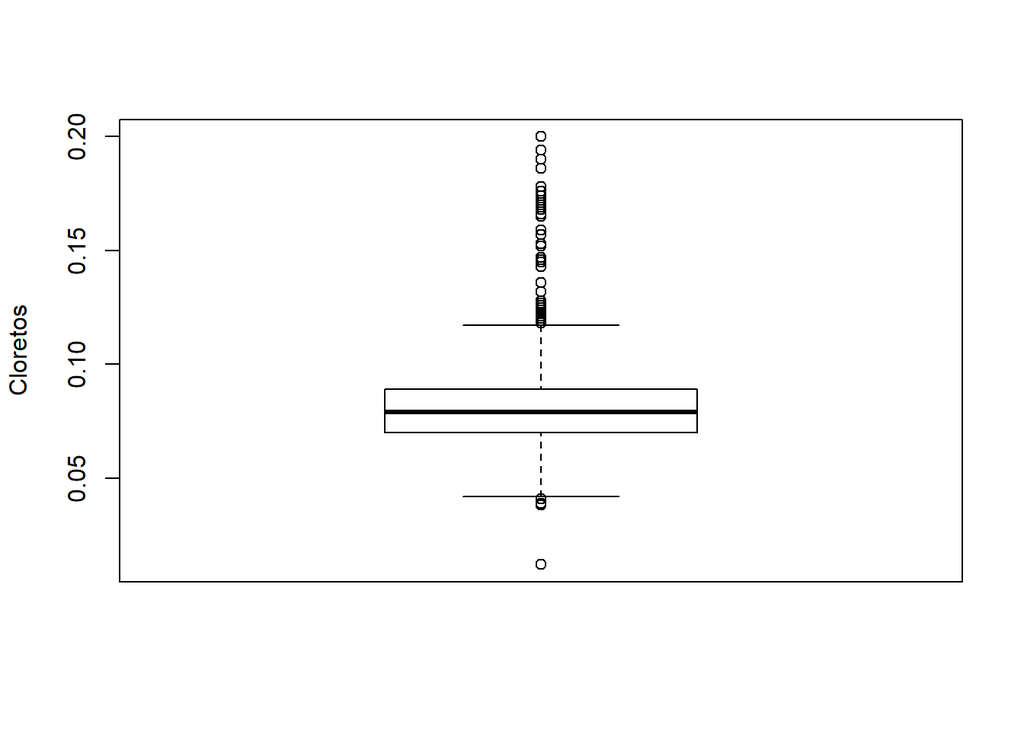

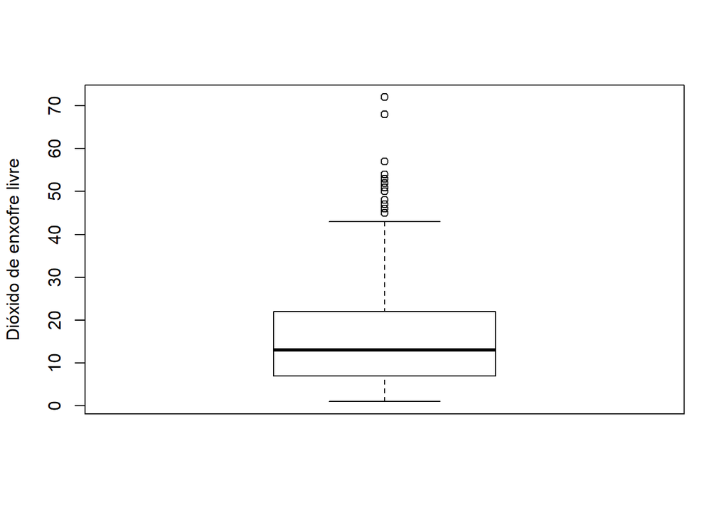

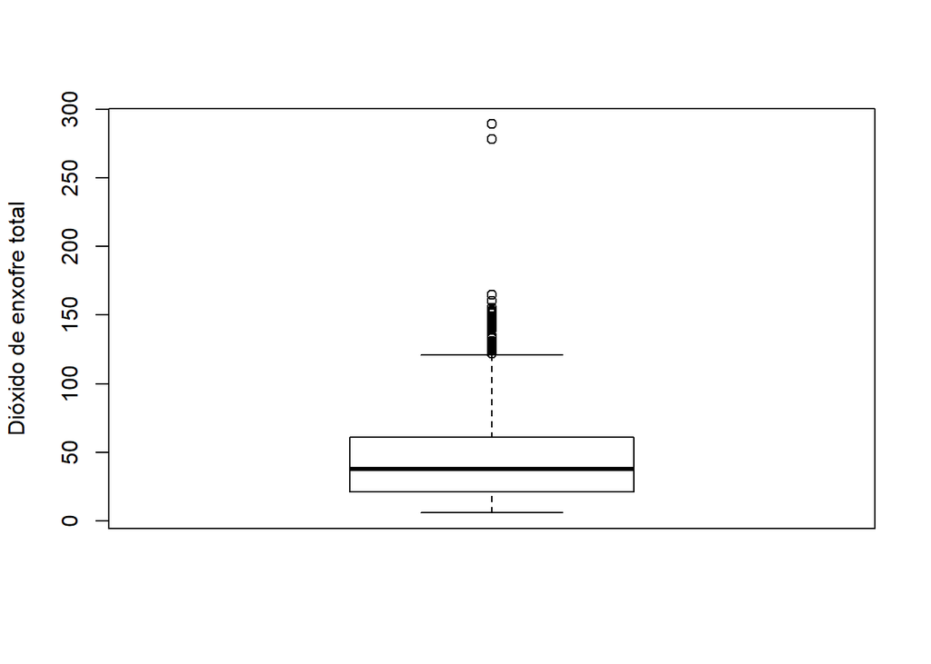

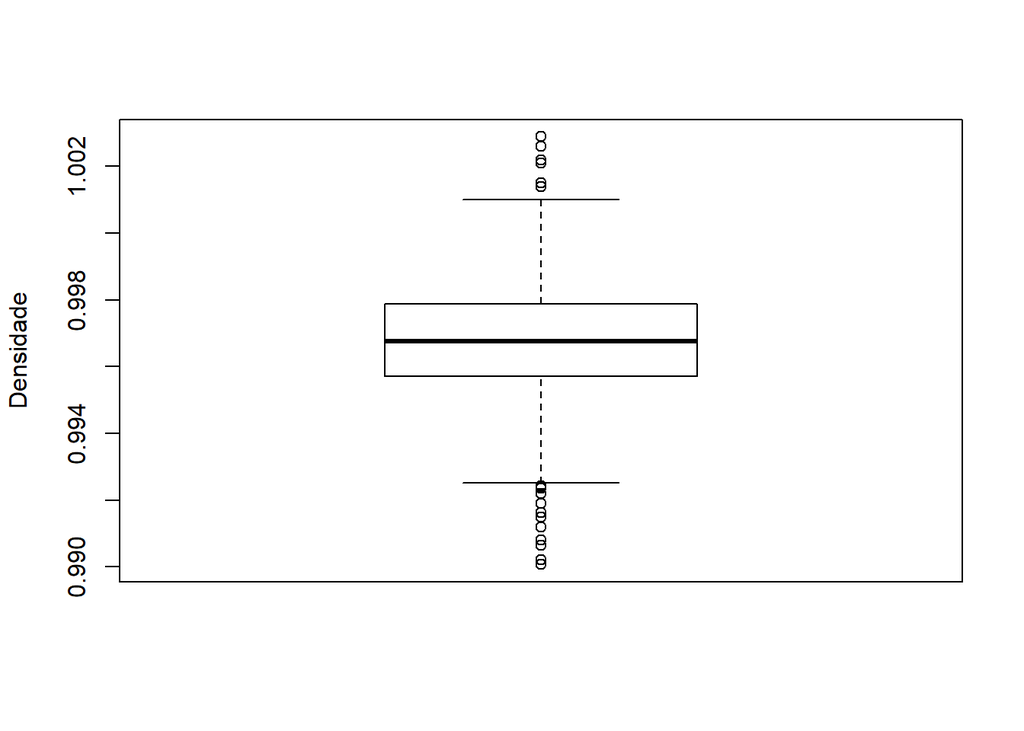

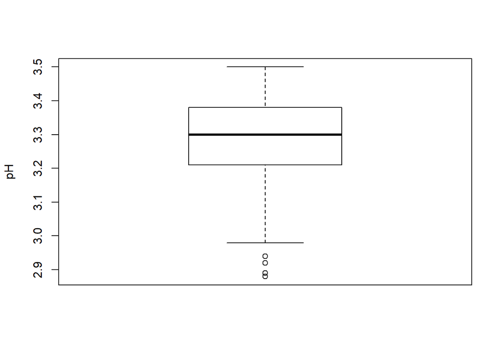

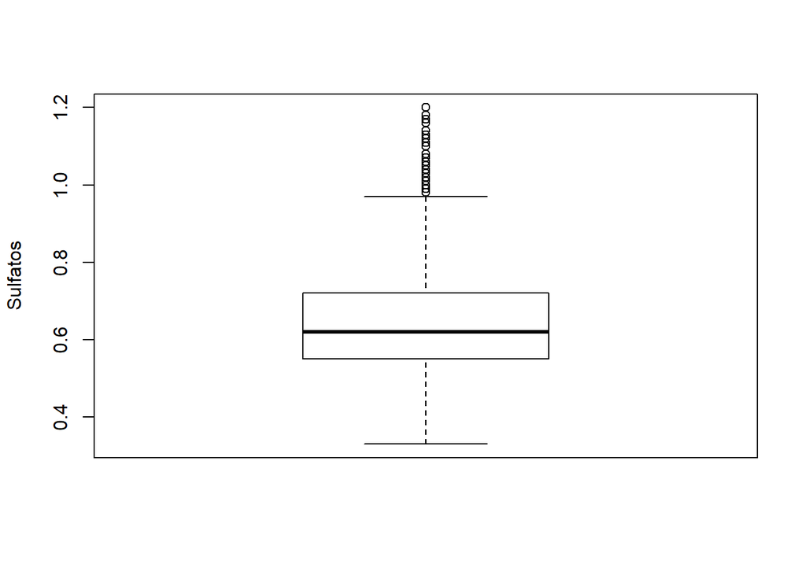

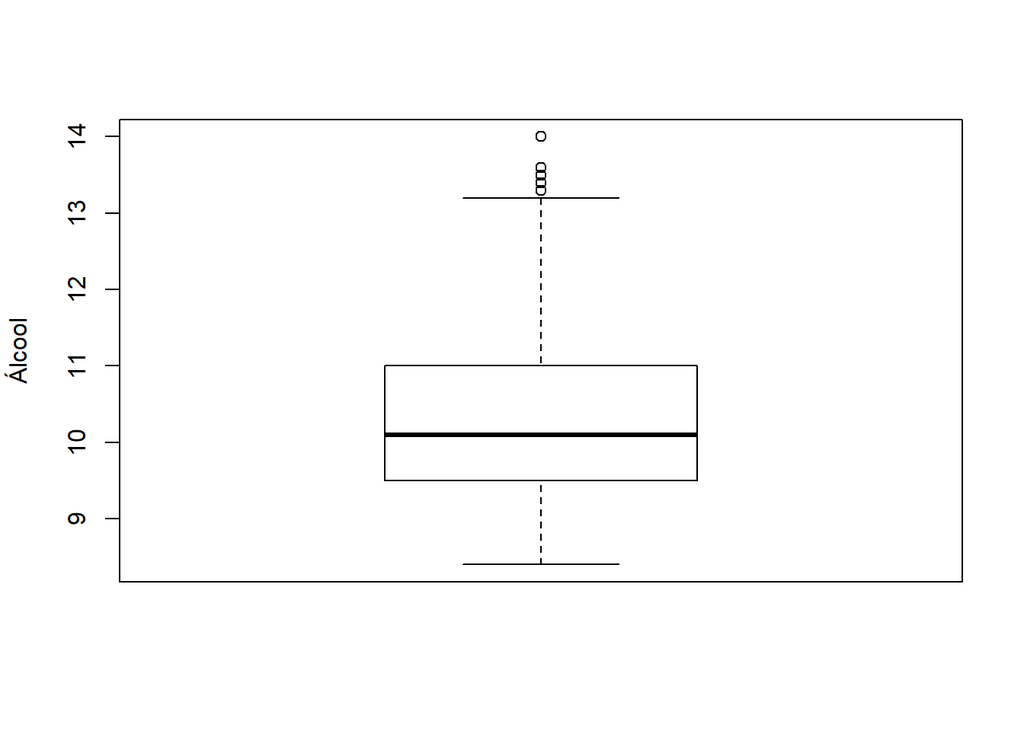

Devido aos dados base já terem sido filtrados nas etapas anteriores não achamos necessário realizar a remoção de mais dados.

Realizamos uma padronização nas variáveis e visualizamos os dados:

```r
Padr_Red <- scale(wineData_Red %>% select(-Vinho,-classificacao, -quality))
summary(Padr_Red)
```

```
##   fixedacidity     volatileacidity      citricacid       residualsugar
##  Min.   :-2.2044   Min.   :-2.31461   Min.   :-1.50695   Min.   :-1.23581
##  1st Qu.:-0.7348   1st Qu.:-0.78708   1st Qu.:-0.86407   1st Qu.:-0.48244
##  Median :-0.2555   Median :-0.02331   Median :-0.06049   Median :-0.25643
##  Mean   : 0.0000   Mean   : 0.00000   Mean   : 0.00000   Mean   : 0.00000
##  3rd Qu.: 0.6071   3rd Qu.: 0.65968   3rd Qu.: 0.79667   3rd Qu.: 0.04492
##  Max.   : 2.9073   Max.   : 4.26554   Max.   : 2.67171   Max.   : 9.76336
##    chlorides       freesulfurdioxide totalsulfurdioxide    density
##  Min.   :-3.4428   Min.   :-1.4187   Min.   :-1.2050    Min.   :-3.81156
##  1st Qu.:-0.5811   1st Qu.:-0.8456   1st Qu.:-0.7581    1st Qu.:-0.61851
##  Median :-0.1370   Median :-0.2726   Median :-0.2517    Median :-0.01166
##  Mean   : 0.0000   Mean   : 0.0000   Mean   : 0.0000    Mean   : 0.00000
##  3rd Qu.: 0.3564   3rd Qu.: 0.5869   3rd Qu.: 0.4335    3rd Qu.: 0.61787
##  Max.   : 5.8332   Max.   : 5.3622   Max.   : 7.2257    Max.   : 3.45929
##        pH            sulphates          alcohol
##  Min.   :-3.5184   Min.   :-2.2745   Min.   :-1.9607
##  1st Qu.:-0.6736   1st Qu.:-0.6749   1st Qu.:-0.8713
##  Median : 0.1022   Median :-0.1660   Median :-0.2770
##  Mean   : 0.0000   Mean   : 0.0000   Mean   : 0.0000
##  3rd Qu.: 0.7919   3rd Qu.: 0.5611   3rd Qu.: 0.6143
##  Max.   : 1.8263   Max.   : 4.0509   Max.   : 3.5855
```

Aqui estamos fazendo o PCA para analisarmos o peso de cada variável:

```r
acpcor <- prcomp(Padr_Red, scale = TRUE)
summary(acpcor)
```

```
## Importance of components:
##                           PC1    PC2    PC3     PC4     PC5     PC6    PC7
## Standard deviation     1.6899 1.4499 1.2855 1.01622 0.96740 0.87177 0.7827
## Proportion of Variance 0.2596 0.1911 0.1502 0.09388 0.08508 0.06909 0.0557
## Cumulative Proportion  0.2596 0.4507 0.6010 0.69485 0.77993 0.84902 0.9047
##                            PC8     PC9   PC10    PC11
## Standard deviation     0.68910 0.57119 0.4234 0.26025
## Proportion of Variance 0.04317 0.02966 0.0163 0.00616
## Cumulative Proportion  0.94788 0.97754 0.9938 1.00000
```

Podemos ver que o o PC10 e PC11 tem um peso menor que os demais,ou seja, podem ser retiradas, no entanto decidimos mantê-las.

Checamos a variação de cada variável:

```r
sum(acpcor$sdev^2)
```

```
## [1] 11
```

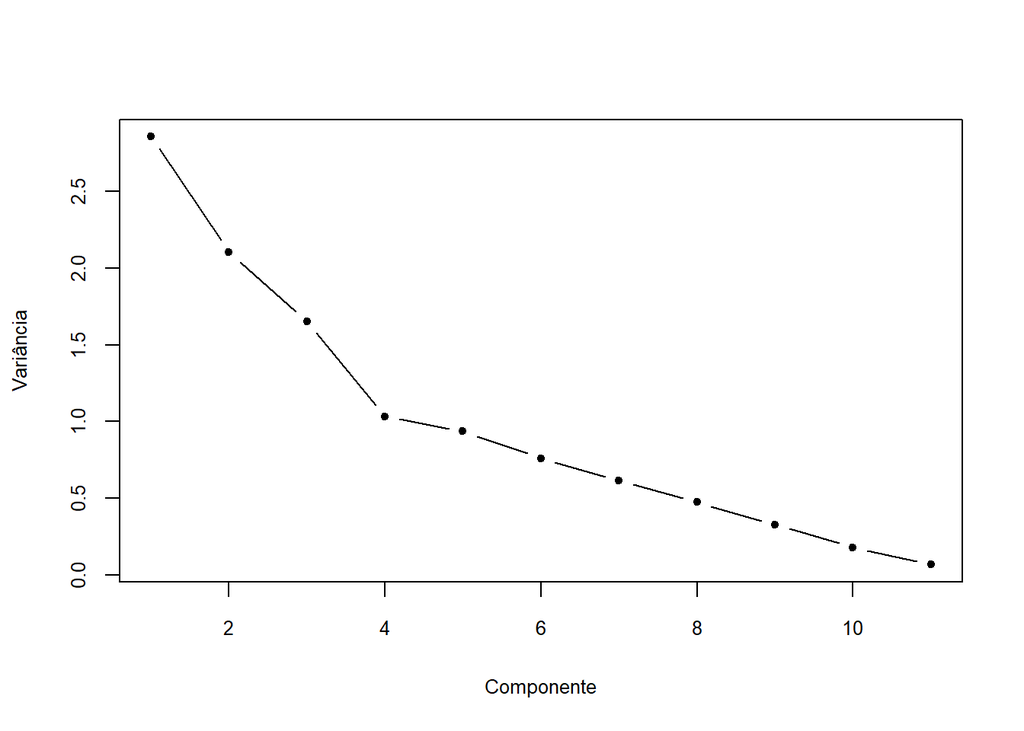

```r
plot(1:ncol(Padr_Red), acpcor$sdev^2, type = "b", xlab = "Componente",
     ylab = "Variância", pch = 20, cex.axis = 0.8, cex.lab = 0.8)
```

Assim como a importância de cada uma no PCA:

```r
acpcor$rotation[, 1:11]
```

```
##                            PC1         PC2         PC3        PC4         PC5
## fixedacidity       -0.52747691  0.05434187 -0.13955526  0.1165877 -0.08516554
## volatileacidity     0.27484285  0.34190590 -0.32389559 -0.1039466 -0.12105054
## citricacid         -0.49773114 -0.10813363  0.18887085  0.1004695 -0.06536999
## residualsugar      -0.11950931  0.21727199  0.22674110 -0.6414132 -0.55560287
## chlorides          -0.12831066  0.33847598 -0.19943880 -0.2021815  0.40938963
## freesulfurdioxide   0.10881992  0.30587149  0.58502399  0.1582694  0.12460649
## totalsulfurdioxide  0.05199635  0.43232214  0.49789495  0.2222226 -0.02945583
## density            -0.34872946  0.41141905 -0.18527421 -0.2403487  0.03718847
## pH                  0.39396160 -0.07863321  0.08780961 -0.4575076  0.24834145
## sulphates          -0.26785479 -0.13482483  0.22537368 -0.3281192  0.62274182
## alcohol            -0.06809964 -0.48228102  0.25646368 -0.2530713 -0.17397611
##                             PC6         PC7         PC8          PC9
## fixedacidity        0.030606422  0.24666789 -0.34967728 -0.203515808
## volatileacidity    -0.203763164  0.63891319 -0.16280644  0.261567732
## citricacid         -0.007248831 -0.22259633 -0.23689583  0.474639282
## residualsugar      -0.020870271 -0.10791030  0.31237207 -0.098184265
## chlorides          -0.686260003 -0.37838910 -0.03893034 -0.046540420
## freesulfurdioxide  -0.034008338  0.10558578 -0.25713172 -0.566632081
## totalsulfurdioxide -0.070580561  0.05617637  0.03897064  0.534998315
## density             0.386803389  0.02714803 -0.25869648 -0.058034082
## pH                  0.307542670 -0.22406842 -0.53626943  0.189075210
## sulphates           0.122827590  0.43245677  0.38289029  0.081538909
## alcohol            -0.469764579  0.27259153 -0.35673403 -0.003732723
##                           PC10        PC11
## fixedacidity       -0.23043991  0.63238936
## volatileacidity     0.36359074  0.01854561
## citricacid          0.59603018 -0.06538770
## residualsugar       0.09814288  0.19510195
## chlorides          -0.02648612  0.04693767
## freesulfurdioxide   0.32911192 -0.06295722
## totalsulfurdioxide -0.45832815  0.07937273
## density            -0.21963649 -0.58886266
## pH                 -0.01922796  0.30235849
## sulphates           0.06177472  0.06810306
## alcohol            -0.27983629 -0.31955396
```

```r
acpcor <- prcomp(Padr_Red, scale = TRUE, retx = TRUE)
```

Escolhemos 2 Centróides, pois queremos classificar os vinhos como BOM e RUIM:

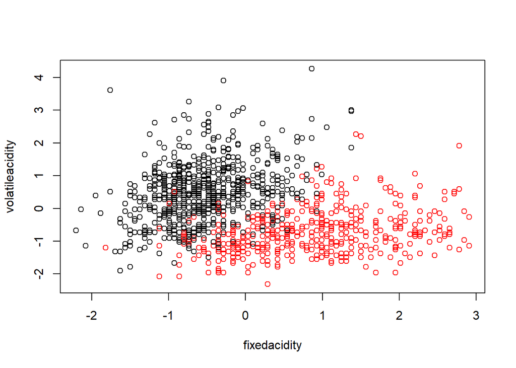

```r
Kcluster <- kmeans(Padr_Red, centers =  2)
plot(Padr_Red, col=Kcluster$cluster)
```